# Comparing CONUS + Global Products

2026-06-29

# Purpose

`GROWdb` is the **CONUS-only** product. It was built largely from U.S.-specific source layers — NHDPlus V2 (flowlines, value-added attributes, EROM flow) and StreamCat (watershed-accumulated landscape metrics), plus USGS gage data. The **global master table** (`site_global_master_table.csv`) re-derives an analogous set of descriptors for the same sampling sites using **global** source layers — HydroSHEDS / HydroBASINS / HydroRIVERS / HydroATLAS, WorldClim 2.1 climatology, Copernicus/ESA land cover, SoilGrids-style soils, and so on.

Because the two products mostly draw on *different underlying datasets*, identical numbers are not expected everywhere. The goal here is narrower and more important: **for variables that represent the same physical concept, confirm the two workflows land in the same place.** Strong agreement on overlapping variables is evidence the global pipeline reproduces the established CONUS pipeline; systematic disagreement flags either a units/definition mismatch or a genuine methodological divergence worth investigating.

Net primary productivity (NPP) has been removed from this exploration because it is no longer part of the variable set.

The comparison is organized as:

1. **Load & join** the two tables on sample identity.
2. **Positive controls** — variables that were carried over from the *same* source in both products. These should agree essentially perfectly and validate the join itself.
3. **Crosswalk** of overlapping-but-different-source variables, with units reconciled.
4. **Quantitative concordance** (n, Pearson r, Spearman ρ, bias, RMSE) per variable.
5. **Visual concordance** — 1:1 scatter and Bland–Altman difference plots.
6. **Land cover** — a dedicated section reconciling Copernicus fractions against aggregated NLCD classes.
7. **Coverage gaps & non-comparable fields** — what could *not* be compared and why.

# Load and join

```r
raw <- read_csv("data/date_lat_long_grow_KKA_05.05.26.csv")
grow  <- read_csv("data/0-shared/GROWdb_20260528.csv", show_col_types = FALSE)
global <- read_csv("data/global_watershed_geospatial/extracted/site_global_master_table.csv",  show_col_types = FALSE)

cat("Master table :", nrow(raw),  "rows x", ncol(raw),  "cols\n")
```

```
## Master table : 527 rows x 4 cols
```

```r
cat("Global table :", nrow(global),  "rows x", ncol(global),  "cols\n")
```

```
## Global table : 527 rows x 176 cols
```

```r
cat("CONUS table:", nrow(grow), "rows x", ncol(grow), "cols\n")
```

```
## CONUS table: 549 rows x 328 cols
```

The two tables share a sample identifier (`sample_name` in the global table, `SampleName` in GROWdb). We join on that. We do **not** join on coordinates, because the two products carry slightly different lat/long precision and rounding, which would silently drop matches.

```r
# Standardise the join key.
global  <- global  %>% rename(sample_id = sample_name)
grow <- grow %>% rename(sample_id = SampleName)

j <- inner_join(global, grow, by = "sample_id", suffix = c("_global", "_grow"))

n_global_only  <- length(setdiff(global$sample_id,  grow$sample_id))
n_grow_only <- length(setdiff(grow$sample_id, global$sample_id))

cat("Matched site-pairs (inner join):", nrow(j), "\n")
```

```
## Matched site-pairs (inner join): 527
```

```r
cat("In global only :", n_global_only, "\n")
```

```
## In global only : 0
```

```r
cat("In GROWdb only :", n_grow_only, "\n")
```

```
## In GROWdb only : 22
```

```r
rows_with_na <- global %>%
  filter(if_any(everything(), is.na))

cat("Rows with at least one NA:", nrow(rows_with_na), "\n")
```

```
## Rows with at least one NA: 451
```

```r
rows_with_na
```

```
## # A tibble: 451 × 176
##    sample_id                 Latitude Longitude Collection_Date delineation_type
##    <chr>                        <dbl>     <dbl> <chr>           <chr>
##  1 altamaha_2019_sw_WHONDRS…     31.7    -81.8  7/31/19         NHD Raindrop Tr…
##  2 arikareeriver_2019_sw_WH…     39.8   -102.   8/6/19          NHD Raindrop Tr…
##  3 assiniboineriver_2019_sw…     49.9    -97.4  8/5/19          HydroSHEDS
##  4 BennetCreek_2020_bw_CO_14     40.7   -106.   10/22/20        NHD Raindrop Tr…
##  5 blackearthcreek_2019_sw_…     43.1    -89.6  8/12/19         NLDI
##  6 blackwarrior_2019_sed_WH…     32.5    -87.8  8/20/19         NHD Raindrop Tr…
##  7 blackwarrior_2019_sw_WHO…     32.5    -87.8  8/20/19         NHD Raindrop Tr…
##  8 blueriver_2019_sed_WHOND…     34.4    -96.6  8/18/19         NHD Raindrop Tr…
##  9 blueriver_2019_sw_WHONDR…     34.4    -96.6  8/18/19         NHD Raindrop Tr…
## 10 blythe_2019_sw_WHONDRS-S…     52.4     -1.70 9/3/19          HydroSHEDS
## # ℹ 441 more rows
## # ℹ 171 more variables: hydrosheds_status <chr>, AreaSqKmWs <dbl>,
## #   HYBAS_ID <dbl>, PFAF_ID <dbl>, pfaf_2 <dbl>, pfaf_4 <dbl>, pfaf_6 <dbl>,
## #   pfaf_8 <dbl>, pfaf_10 <dbl>, SUB_AREA <dbl>, UP_AREA <dbl>, HYRIV_ID <dbl>,
## #   StreamOrder <dbl>, DischargeCMS <dbl>, MainRiv <dbl>,
## #   elevation_mean_m <dbl>, elevation_min_m <dbl>, elevation_max_m <dbl>,
## #   elevation_sd_m <dbl>, mean.wc2.1_2.5m_prec_01 <dbl>, …
```

```r
na_by_row <- global %>%
  mutate(
    na_cols = pmap_chr(
      across(everything()),
      ~ names(global)[map_lgl(list(...), is.na)] %>% paste(collapse = ", ")
    )
  ) %>%
  filter(na_cols != "")

na_by_row %>%
  select(sample_id, na_cols)
```

```
## # A tibble: 451 × 2
##    sample_id                                  na_cols
##    <chr>                                      <chr>
##  1 altamaha_2019_sw_WHONDRS-S19S_0010         notes
##  2 arikareeriver_2019_sw_WHONDRS-S19S_0023    notes
##  3 assiniboineriver_2019_sw_WHONDRS-S19S_0005 notes
##  4 BennetCreek_2020_bw_CO_14                  notes
##  5 blackearthcreek_2019_sw_WHONDRS-S19S_0061  notes
##  6 blackwarrior_2019_sed_WHONDRS-S19S_0021    notes
##  7 blackwarrior_2019_sw_WHONDRS-S19S_0021     notes
##  8 blueriver_2019_sed_WHONDRS-S19S_0024       notes
##  9 blueriver_2019_sw_WHONDRS-S19S_0024        notes
## 10 blythe_2019_sw_WHONDRS-S19S_0092           HYRIV_ID, DischargeCMS, MainRiv, …
## # ℹ 441 more rows
```

```r
na_summary <- global %>%
  summarise(across(everything(), ~ sum(is.na(.x)))) %>%
  pivot_longer(
    everything(),
    names_to = "column",
    values_to = "n_na"
  ) %>%
  filter(n_na > 0) %>%
  arrange(desc(n_na))

na_summary
```

```
## # A tibble: 13 × 2
##    column        n_na
##    <chr>        <int>
##  1 notes          446
##  2 HYRIV_ID        49
##  3 DischargeCMS    49
##  4 MainRiv         49
##  5 HYBAS_ID         3
##  6 PFAF_ID          3
##  7 pfaf_2           3
##  8 pfaf_4           3
##  9 pfaf_6           3
## 10 pfaf_8           3
## 11 pfaf_10          3
## 12 SUB_AREA         3
## 13 UP_AREA          3
```

```r
# ---- Derived / unit-reconciled columns ------------------------------------
# Annual WorldClim climate summaries are now added in the post-processing
# workflow, so this exploration uses those columns directly instead of
# recalculating them from the 12 monthly layers.

# Pull the first available version of a column. This makes the exploration
# tolerant to join suffixes and to the recent global table name updates.
col_num <- function(data, candidates) {
  hit <- candidates[candidates %in% names(data)][1]
  if (is.na(hit)) {
    return(rep(NA_real_, nrow(data)))
  }
  suppressWarnings(as.numeric(data[[hit]]))
}

j <- j %>%
  mutate(
    # Standardized global columns used by the comparison specs below.
    global_area_sqkm_ws = col_num(., c("AreaSqKmWs", "AreaSqKmWs_global", "WsAreaSqKm", "WsAreaSqKm_global")),

    global_precip_site_annual_mm = col_num(., c("precipSite_annual_sum_mm", "precipSite_annual_sum_mm_global")),
    global_tmean_site_annual_c   = col_num(., c("tmeanSite_annual_mean_c",  "tmeanSite_annual_mean_c_global")),
    global_tmax_site_annual_c    = col_num(., c("tmaxSite_annual_mean_c",   "tmaxSite_annual_mean_c_global")),
    global_tmin_site_annual_c    = col_num(., c("tminSite_annual_mean_c",   "tminSite_annual_mean_c_global")),

    global_precip_ws_annual_mm = col_num(., c("precipWs_annual_sum_mm", "precipWs_annual_sum_mm_global")),
    global_tmean_ws_annual_c   = col_num(., c("tmeanWs_annual_mean_c",  "tmeanWs_annual_mean_c_global")),
    global_tmax_ws_annual_c    = col_num(., c("tmaxWs_annual_mean_c",   "tmaxWs_annual_mean_c_global")),
    global_tmin_ws_annual_c    = col_num(., c("tminWs_annual_mean_c",   "tminWs_annual_mean_c_global")),

    # GROWdb discharge is in cubic feet/sec; convert to CMS to match global.
    grow_qe_ma_cms = if ("qe_ma" %in% names(.)) qe_ma * 0.0283168 else NA_real_,
    grow_CFS_cms   = if ("CFS"   %in% names(.)) CFS   * 0.0283168 else NA_real_,

    # NHDPlus smoothed elevations are in centimetres; convert to metres.
    grow_minelev_m = if ("minelevsmo" %in% names(.)) minelevsmo / 100 else NA_real_
  )
```

# Positive controls: variables sharing a source

A handful of fields were populated from the **same** source dataset in both products (e.g. aridity index). They are the control group: if the join is correct and no transformation crept in, they should be effectively identical (r ≈ 1, bias ≈ 0). Any failure here would mean the rest of the comparison can’t be trusted.

```r
# ---- Core concordance helper ----------------------------------------------
compare_pair <- function(data, x_col, y_col) {
  if (!all(c(x_col, y_col) %in% names(data))) {
    return(tibble(n = 0L, pearson_r = NA, spearman_rho = NA,
                  bias_grow_minus_global = NA, rmse = NA,
                  global_median = NA, grow_median = NA))
  }
  x <- suppressWarnings(as.numeric(data[[x_col]]))
  y <- suppressWarnings(as.numeric(data[[y_col]]))
  ok <- is.finite(x) & is.finite(y)
  x <- x[ok]; y <- y[ok]
  n <- length(x)
  if (n < 3) {
    return(tibble(n = n, pearson_r = NA, spearman_rho = NA,
                  bias_grow_minus_global = NA, rmse = NA,
                  global_median = NA, grow_median = NA))
  }
  tibble(
    n = n,
    pearson_r           = suppressWarnings(cor(x, y, method = "pearson")),
    spearman_rho        = suppressWarnings(cor(x, y, method = "spearman")),
    bias_grow_minus_global = mean(y - x),
    rmse                = sqrt(mean((y - x)^2)),
    global_median          = median(x),
    grow_median         = median(y)
  )
}

# Build a results table from a spec tibble:
#   concept | category | x_col (global) | y_col (grow) | unit | note
run_specs <- function(data, specs) {
  specs %>%
    mutate(stats = pmap(list(x_col, y_col), ~ compare_pair(data, ..1, ..2))) %>%
    unnest(stats) %>%
    select(category, concept, unit, n, pearson_r, spearman_rho,
           bias_grow_minus_global, rmse, global_median, grow_median, note)
}
```

```r
control_specs <- tribble(
  ~concept,                 ~category,  ~x_col,              ~y_col,             ~unit,   ~note,
  "Aridity (watershed)",    "Control",  "AridityWs_global",   "AridityWs_grow",   "index", "Same source layer in both products",
  "Aridity (site)",         "Control",  "AriditySite_global", "AriditySite_grow", "index", "Same source layer in both products"
)

control_res <- run_specs(j, control_specs)
kableExtra::kable(control_res %>% select(-category),
           caption = "Positive controls (shared-source variables). Expect r ~ 1.")
```

Positive controls (shared-source variables). Expect r ~ 1.

| concept | unit | n | pearson_r | spearman_rho | bias_grow_minus_global | rmse | global_median | grow_median | note |
| --- | --- | --- | --- | --- | --- | --- | --- | --- | --- |
| Aridity (watershed) | index | 389 | 1 | 1 | 0 | 0 | 0.8286357 | 0.8286357 | Same source layer in both products |
| Aridity (site) | index | 403 | 1 | 1 | 0 | 0 | 0.7919000 | 0.7919000 | Same source layer in both products |

> **Read this first.** If the control rows above do not show r ≈ 1 and bias ≈ 0, stop — the join or a unit transform is wrong and the downstream comparisons are not interpretable. If they do, the join is sound and the matched-site values are aligned.

# Crosswalk of overlapping variables

The table below is the conceptual map between the two products for variables that come from **different** source datasets but describe the same quantity. Units are reconciled to a common basis in the `x_col`/`y_col` referenced by the analysis.

Conceptual crosswalk between the two products.

| Concept | Global source | GROWdb source | Unit reconciliation |
| --- | --- | --- | --- |
| Watershed / drainage area | HydroSHEDS upstream area | NHDPlus V2 totdasqkm | both km^2 (none) |
| Stream order | HydroRIVERS Strahler | NHDPlus streamorde (Strahler) | none |
| Mean annual discharge | HydroATLAS DischargeCMS | NHDPlus EROM qe_ma | GROW CFS -> CMS (x0.0283168) |
| Discharge (gage) | HydroATLAS DischargeCMS | USGS gage CFS | GROW CFS -> CMS (x0.0283168) |
| Site elevation | DEM ElevationSite (m) | NHDPlus minelevsmo (cm) | GROW cm -> m (/100); reach vs point |
| Site precip (annual) | WorldClim 2.1 annual summary | StreamCat/Daymet PrecipSite | annual sum, mm/yr |
| Site tmean (annual) | WorldClim 2.1 annual summary | StreamCat/Daymet TmeanSite | annual mean, degC |
| Site tmax (annual) | WorldClim 2.1 annual summary | StreamCat/Daymet TmaxSite | annual mean, degC |
| Site tmin (annual) | WorldClim 2.1 annual summary | StreamCat/Daymet TminSite | annual mean, degC |
| Watershed clay | SoilGrids ClayWs | StreamCat ClayWs | both % |
| Watershed sand | SoilGrids SandWs | StreamCat SandWs | both % |
| Watershed dam density | GOODD/GRanD DamDensWs | StreamCat (NID) DamDensWs | different inventories |
| Land cover (watershed) | Copernicus/ESA fractions (0-1) | NLCD 2016 class % (StreamCat) | fraction*100 vs aggregated NLCD % |

```r
overlap_specs <- tribble(
  ~concept,                 ~category,       ~x_col,                  ~y_col,             ~unit,        ~note,
  "Watershed area",         "Delineation",   "global_area_sqkm_ws",       "totdasqkm",        "km^2",       "HydroSHEDS vs NHDPlus totdasqkm",
  "Stream order",           "Network",       "StreamOrder",           "streamorde",       "Strahler",   "HydroRIVERS vs NHDPlus",
  "Discharge (modeled)",    "Hydrology",     "DischargeCMS",          "grow_qe_ma_cms",   "m^3/s",      "HydroATLAS vs NHDPlus EROM",
  "Discharge (gage)",       "Hydrology",     "DischargeCMS",          "grow_CFS_cms",     "m^3/s",      "HydroATLAS vs USGS gage",
  "Site elevation",         "Terrain",       "ElevationSite",         "grow_minelev_m",   "m",          "Point DEM vs NHDPlus reach min (cm->m)",
  "Site precip (annual)",   "Climate",       "global_precip_site_annual_mm", "PrecipSite",       "mm/yr",      "WorldClim annual summary vs Daymet/StreamCat",
  "Site tmean (annual)",    "Climate",       "global_tmean_site_annual_c",   "TmeanSite",        "degC",       "WorldClim annual summary vs Daymet/StreamCat",
  "Site tmax (annual)",     "Climate",       "global_tmax_site_annual_c",    "TmaxSite",         "degC",       "WorldClim annual summary vs Daymet/StreamCat",
  "Site tmin (annual)",     "Climate",       "global_tmin_site_annual_c",    "TminSite",         "degC",       "WorldClim annual summary vs Daymet/StreamCat",
  "Watershed clay",         "Soil",          "ClayWs_global",            "ClayWs_grow",      "%",          "SoilGrids vs StreamCat",
  "Watershed sand",         "Soil",          "SandWs_global",            "SandWs_grow",      "%",          "SoilGrids vs StreamCat",
  "Watershed dam density",  "Human impact",  "DamDensWs_global",         "DamDensWs_grow",   "dams/km^2",  "GOODD/GRanD vs NID; divergence expected"
)

overlap_res <- run_specs(j, overlap_specs)
nice_table(overlap_res %>% select(-category),
           caption = "Concordance of overlapping (different-source) variables.")
```

Concordance of overlapping (different-source) variables.

| concept | unit | n | pearson_r | spearman_rho | bias_grow_minus_global | rmse | global_median | grow_median | note |
| --- | --- | --- | --- | --- | --- | --- | --- | --- | --- |
| Watershed area | km^2 | 372 | 1.000 | 1.000 | -3281.929 | 13399.570 | 2735.317 | 2730.931 | HydroSHEDS vs NHDPlus totdasqkm |
| Stream order | Strahler | 372 | 0.937 | 0.935 | 0.642 | 1.056 | 5.000 | 5.000 | HydroRIVERS vs NHDPlus |
| Discharge (modeled) | m^3/s | 358 | 0.965 | 0.858 | -104.570 | 1047.418 | 48.947 | 29.442 | HydroATLAS vs NHDPlus EROM |
| Discharge (gage) | m^3/s | 248 | 0.862 | 0.888 | -188.965 | 1774.998 | 90.571 | 33.697 | HydroATLAS vs USGS gage |
| Site elevation | m | 372 | 0.995 | 0.969 | -77.003 | 127.166 | 240.000 | 159.280 | Point DEM vs NHDPlus reach min (cm->m) |
| Site precip (annual) | mm/yr | 403 | 0.970 | 0.971 | 39.169 | 120.758 | 1019.000 | 1057.140 | WorldClim annual summary vs Daymet/StreamCat |
| Site tmean (annual) | degC | 403 | 0.995 | 0.984 | 0.471 | 0.728 | 10.451 | 10.730 | WorldClim annual summary vs Daymet/StreamCat |
| Site tmax (annual) | degC | 403 | 0.992 | 0.989 | 0.347 | 0.687 | 16.659 | 16.860 | WorldClim annual summary vs Daymet/StreamCat |
| Site tmin (annual) | degC | 403 | 0.994 | 0.981 | 0.591 | 0.915 | 4.098 | 4.580 | WorldClim annual summary vs Daymet/StreamCat |
| Watershed clay | % | 372 | 0.888 | 0.864 | -0.530 | 4.420 | 20.446 | 20.049 | SoilGrids vs StreamCat |
| Watershed sand | % | 372 | 0.831 | 0.854 | -4.369 | 9.003 | 43.324 | 35.621 | SoilGrids vs StreamCat |
| Watershed dam density | dams/km^2 | 372 | 0.662 | 0.661 | 0.008 | 0.015 | 0.001 | 0.004 | GOODD/GRanD vs NID; divergence expected |

## Concordance summary, ranked

```r
all_res <- bind_rows(control_res, overlap_res) %>%
  arrange(desc(pearson_r))

# Classify agreement into interpretable tiers.
tiered <- all_res %>%
  mutate(agreement = case_when(
    is.na(pearson_r)        ~ "no data",
    pearson_r >= 0.98       ~ "near-identical",
    pearson_r >= 0.90       ~ "strong",
    pearson_r >= 0.75       ~ "moderate",
    TRUE                    ~ "weak / divergent"
  )) %>%
  select(category, concept, agreement, n, pearson_r, spearman_rho,
         bias_grow_minus_global, rmse)

nice_table(tiered, caption = "All comparisons ranked by Pearson correlation, with agreement tier.")
```

All comparisons ranked by Pearson correlation, with agreement tier.

| category | concept | agreement | n | pearson_r | spearman_rho | bias_grow_minus_global | rmse |
| --- | --- | --- | --- | --- | --- | --- | --- |
| Control | Aridity (watershed) | near-identical | 389 | 1.000 | 1.000 | 0.000 | 0.000 |
| Control | Aridity (site) | near-identical | 403 | 1.000 | 1.000 | 0.000 | 0.000 |
| Delineation | Watershed area | near-identical | 372 | 1.000 | 1.000 | -3281.929 | 13399.570 |
| Terrain | Site elevation | near-identical | 372 | 0.995 | 0.969 | -77.003 | 127.166 |
| Climate | Site tmean (annual) | near-identical | 403 | 0.995 | 0.984 | 0.471 | 0.728 |
| Climate | Site tmin (annual) | near-identical | 403 | 0.994 | 0.981 | 0.591 | 0.915 |
| Climate | Site tmax (annual) | near-identical | 403 | 0.992 | 0.989 | 0.347 | 0.687 |
| Climate | Site precip (annual) | strong | 403 | 0.970 | 0.971 | 39.169 | 120.758 |
| Hydrology | Discharge (modeled) | strong | 358 | 0.965 | 0.858 | -104.570 | 1047.418 |
| Network | Stream order | strong | 372 | 0.937 | 0.935 | 0.642 | 1.056 |
| Soil | Watershed clay | moderate | 372 | 0.888 | 0.864 | -0.530 | 4.420 |
| Hydrology | Discharge (gage) | moderate | 248 | 0.862 | 0.888 | -188.965 | 1774.998 |
| Soil | Watershed sand | moderate | 372 | 0.831 | 0.854 | -4.369 | 9.003 |
| Human impact | Watershed dam density | weak / divergent | 372 | 0.662 | 0.661 | 0.008 | 0.015 |

Count of variables by agreement tier.

| agreement | n |
| --- | --- |
| near-identical | 7 |
| strong | 3 |
| moderate | 3 |
| weak / divergent | 1 |

# Visual concordance

## 1:1 scatter plots

Each panel plots the GROWdb value (y) against the global value (x) on a shared physical scale, with the dashed 1:1 line. Points hugging the line mean the two workflows agree; a consistent slope away from the line means a scale/units issue; scatter means methodological divergence.

```r
# Long tidy frame of matched values for every overlapping concept.
make_pairs <- function(data, specs) {
  specs %>%
    pmap_dfr(function(concept, category, x_col, y_col, unit, note) {
      if (!all(c(x_col, y_col) %in% names(data))) return(tibble())
      tibble(
        concept  = concept,
        category = category,
        unit     = unit,
        global      = suppressWarnings(as.numeric(data[[x_col]])),
        grow     = suppressWarnings(as.numeric(data[[y_col]]))
      )
    }) %>%
    filter(is.finite(global), is.finite(grow))
}

pairs_long <- make_pairs(j, overlap_specs)
```

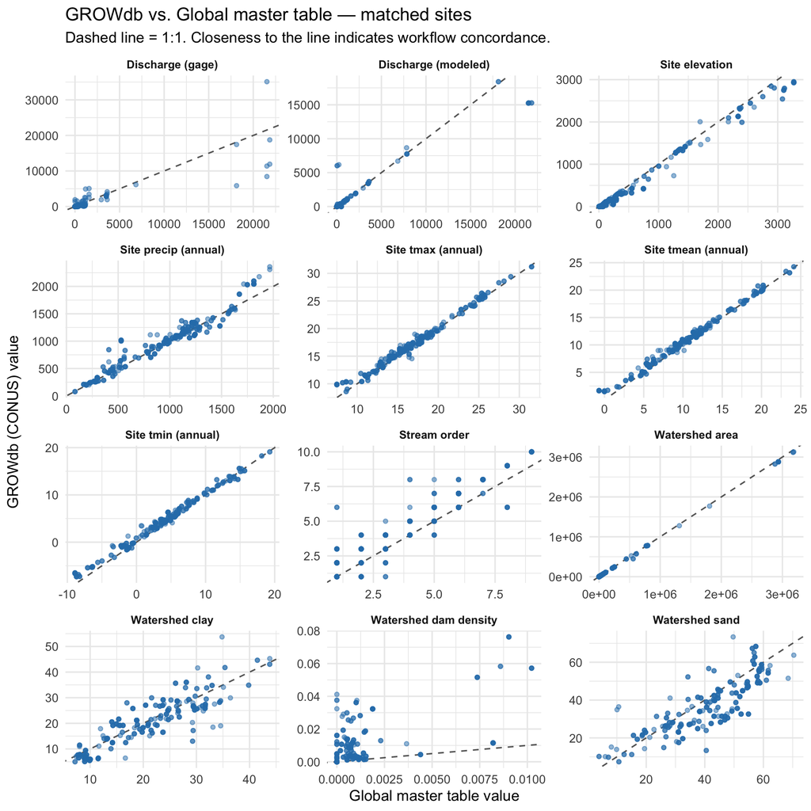

```r
ggplot(pairs_long, aes(global, grow)) +
  geom_abline(slope = 1, intercept = 0, linetype = "dashed", colour = "grey40") +
  geom_point(alpha = 0.5, size = 1.3, colour = "#2c7fb8") +
  facet_wrap(~ concept, scales = "free", ncol = 3) +
  labs(
    title = "GROWdb vs. Global master table — matched sites",
    subtitle = "Dashed line = 1:1. Closeness to the line indicates workflow concordance.",
    x = "Global master table value",
    y = "GROWdb (CONUS) value"
  ) +
  theme(strip.text = element_text(face = "bold", size = 9))
```

Several of these quantities (area, discharge) span orders of magnitude, so a log–log view separates the high-agreement structure from the few large basins that dominate a linear axis.

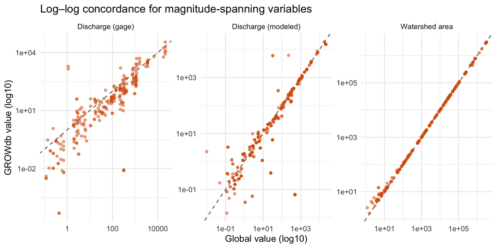

```r
log_concepts <- c("Watershed area", "Discharge (modeled)", "Discharge (gage)")
pairs_long %>%
  filter(concept %in% log_concepts, global > 0, grow > 0) %>%
  ggplot(aes(global, grow)) +
  geom_abline(slope = 1, intercept = 0, linetype = "dashed", colour = "grey40") +
  geom_point(alpha = 0.5, size = 1.3, colour = "#d95f0e") +
  scale_x_log10() + scale_y_log10() +
  facet_wrap(~ concept, scales = "free", ncol = 3) +
  labs(title = "Log–log concordance for magnitude-spanning variables",
       x = "Global value (log10)", y = "GROWdb value (log10)")
```

## Bland–Altman (difference) plots

For the well-matched variables, a Bland–Altman view (difference vs. mean) makes any *systematic* bias or magnitude-dependent drift visible in a way a correlation cannot.

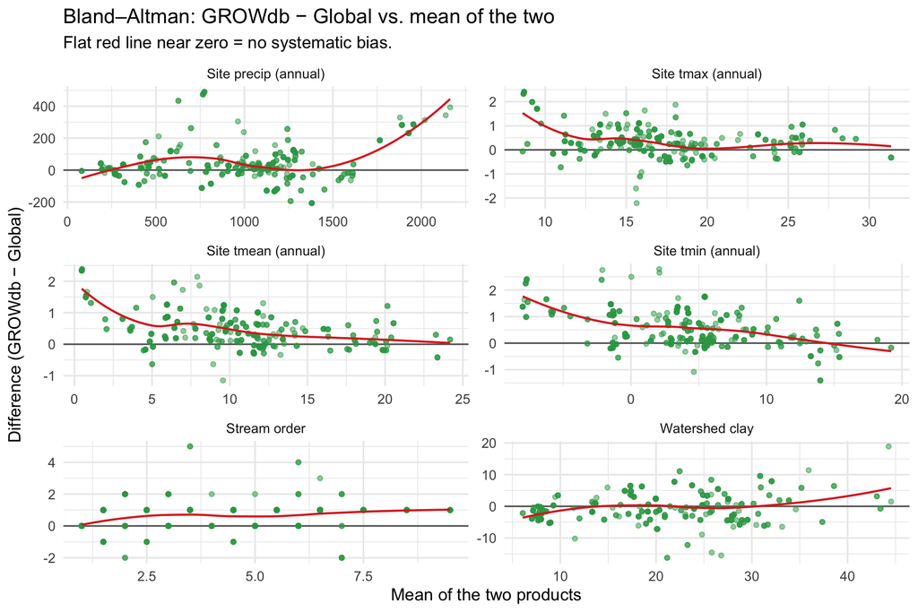

```r
ba_concepts <- c("Site precip (annual)", "Site tmean (annual)",
                 "Site tmax (annual)", "Site tmin (annual)",
                 "Watershed clay", "Stream order")
pairs_long %>%
  filter(concept %in% ba_concepts) %>%
  mutate(mean_val = (global + grow) / 2,
         diff_val = grow - global) %>%
  ggplot(aes(mean_val, diff_val)) +
  geom_hline(yintercept = 0, colour = "grey40") +
  geom_point(alpha = 0.5, size = 1.3, colour = "#31a354") +
  geom_smooth(method = "loess", se = FALSE, colour = "#de2d26", linewidth = 0.7) +
  facet_wrap(~ concept, scales = "free", ncol = 2) +
  labs(title = "Bland–Altman: GROWdb − Global vs. mean of the two",
       subtitle = "Flat red line near zero = no systematic bias.",
       x = "Mean of the two products", y = "Difference (GROWdb − Global)")
```

# Land cover: Copernicus fractions vs. NLCD classes

Land cover is the clearest case of *different products measuring the same thing*: the global table uses Copernicus/ESA continuous cover fractions (0–1), while GROWdb uses NLCD 2016 class percentages from StreamCat. To compare, NLCD classes are aggregated into the broad groups the Copernicus fractions represent, and the global fractions are rescaled to percent.

```r
# NLCD classes are aggregated with rowSums(across(any_of(...))) so that any
# class column absent from a given GROWdb export is skipped rather than erroring.
lc <- j %>%
  transmute(
    sample_id = sample_id,

    # ---- Forest ----
    global_forest  = 100 * `lc_trees_mean_fraction`,
    grow_forest = rowSums(across(any_of(c("PctDecid2016Ws","PctConif2016Ws","PctMxFst2016Ws")))),

    # ---- Cropland (incl. pasture/hay) ----
    global_crop    = 100 * `lc_cropland_mean_fraction`,
    grow_crop   = rowSums(across(any_of(c("PctCrop2016Ws","PctHay2016Ws")))),

    # ---- Grass + shrub ----
    global_grshrub = 100 * (`lc_grassland_mean_fraction` + `lc_shrubs_mean_fraction`),
    grow_grshrub= rowSums(across(any_of(c("PctGrs2016Ws","PctShrb2016Ws")))),

    # ---- Developed / built ----
    global_built   = 100 * `lc_built_mean_fraction`,
    grow_built  = rowSums(across(any_of(c("PctUrbOp2016Ws","PctUrbLo2016Ws","PctUrbMd2016Ws","PctUrbHi2016Ws")))),

    # ---- Open water ----
    global_water   = 100 * `lc_water_mean_fraction`,
    grow_water  = rowSums(across(any_of(c("PctOw2016Ws")))),

    # ---- Wetland ----
    global_wetland = 100 * `lc_wetland_mean_fraction`,
    grow_wetland= rowSums(across(any_of(c("PctWdWet2016Ws","PctHbWet2016Ws"))))
  )

lc_specs <- tribble(
  ~concept,        ~category,    ~x_col,        ~y_col,         ~unit, ~note,
  "Forest %",      "Land cover", "global_forest",  "grow_forest",  "%",   "Copernicus trees vs NLCD forest classes",
  "Cropland %",    "Land cover", "global_crop",    "grow_crop",    "%",   "Copernicus cropland vs NLCD crop+hay",
  "Grass+shrub %", "Land cover", "global_grshrub", "grow_grshrub", "%",   "Copernicus grass+shrub vs NLCD grass+shrub",
  "Developed %",   "Land cover", "global_built",   "grow_built",   "%",   "Copernicus built vs NLCD urban classes",
  "Open water %",  "Land cover", "global_water",   "grow_water",   "%",   "Copernicus water vs NLCD open water",
  "Wetland %",     "Land cover", "global_wetland", "grow_wetland", "%",   "Copernicus wetland vs NLCD woody+herb wetland"
)

lc_res <- run_specs(lc, lc_specs)
nice_table(lc_res %>% select(-category),
           caption = "Land cover concordance: Copernicus fractions vs aggregated NLCD 2016.")
```

Land cover concordance: Copernicus fractions vs aggregated NLCD 2016.

| concept | unit | n | pearson_r | spearman_rho | bias_grow_minus_global | rmse | global_median | grow_median | note |
| --- | --- | --- | --- | --- | --- | --- | --- | --- | --- |
| Forest % | % | 372 | 0.936 | 0.938 | -10.889 | 15.140 | 71.586 | 55.655 | Copernicus trees vs NLCD forest classes |
| Cropland % | % | 372 | 0.933 | 0.931 | 5.562 | 9.697 | 1.142 | 4.290 | Copernicus cropland vs NLCD crop+hay |
| Grass+shrub % | % | 372 | 0.891 | 0.663 | -0.969 | 10.809 | 13.083 | 11.850 | Copernicus grass+shrub vs NLCD grass+shrub |
| Developed % | % | 372 | 0.901 | 0.825 | 4.509 | 7.625 | 0.552 | 3.370 | Copernicus built vs NLCD urban classes |
| Open water % | % | 372 | 0.970 | 0.975 | 0.097 | 0.273 | 0.552 | 0.600 | Copernicus water vs NLCD open water |
| Wetland % | % | 372 | 0.735 | 0.596 | 3.978 | 7.467 | 0.019 | 2.060 | Copernicus wetland vs NLCD woody+herb wetland |

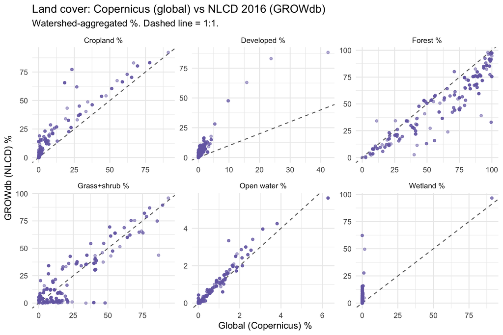

```r
lc_pairs <- make_pairs(lc, lc_specs)
ggplot(lc_pairs, aes(global, grow)) +
  geom_abline(slope = 1, intercept = 0, linetype = "dashed", colour = "grey40") +
  geom_point(alpha = 0.5, size = 1.3, colour = "#756bb1") +
  facet_wrap(~ concept, scales = "free", ncol = 3) +
  labs(title = "Land cover: Copernicus (global) vs NLCD 2016 (GROWdb)",
       subtitle = "Watershed-aggregated %. Dashed line = 1:1.",
       x = "Global (Copernicus) %", y = "GROWdb (NLCD) %")
```

> Land cover agreement is expected to be *good but not perfect*: the two products use different sensors, epochs, and class definitions. The useful question is whether the **rank ordering and broad magnitude** of cover types are preserved (high Spearman ρ), not whether they match to the percentage point.

# Coverage gaps and non-comparable fields

Not every conceptually-shared field could be compared. These are documented so the gaps are explicit rather than silent.

Coverage of selected GROWdb fields on the matched sites.

| GROWdb field | present | n_nonNA | status |
| --- | --- | --- | --- |
| WsAreaSqKm | TRUE | 0 | present but empty for matched sites |
| AreaSqKmWs | FALSE | NA | column absent |
| PrecipWs | TRUE | 0 | present but empty for matched sites |
| TmeanWs | TRUE | 0 | present but empty for matched sites |
| TmaxWs | TRUE | 0 | present but empty for matched sites |
| TminWs | TRUE | 0 | present but empty for matched sites |
| CatAreaSqKm | TRUE | 0 | present but empty for matched sites |
| CFS | TRUE | 255 | populated |
| gage_id | TRUE | 268 | populated |

Notes on what was routed around or excluded:

- **GROWdb `WsAreaSqKm` may be empty** for the matched rows; the StreamCat watershed-area field was not carried. Watershed area is therefore compared against NHDPlus `totdasqkm` (total upstream drainage area), which is the correct conceptual analogue to the global upstream area.
- **Annual climate summaries are now read directly from the global table** (`precipSite_annual_sum_mm`, `tmeanSite_annual_mean_c`, `tmaxSite_annual_mean_c`, `tminSite_annual_mean_c`, and corresponding watershed summaries). GROWdb watershed climate fields (`PrecipWs`, `TmeanWs`, `TmaxWs`, `TminWs`) are empty for the matched rows, so climate concordance is still assessed at the **site** (point) level only.
- **Ecoregion / biome** are *not* numerically comparable: the global table uses WWF ecoregions/biomes/realms (`EcoregionSite`, `BiomeSite`, `RealmSite`), while GROWdb uses Omernik Levels I–III (`OmernikISite`…`OmernikIIIWs`). These are different classification taxonomies; a value-for-value comparison is meaningless. A cross-tabulation could check whether the two schemes partition sites consistently, but that is a categorical-agreement question outside the scope of this numeric workflow check.
- **Site-level soil** (`ClaySite`, `SandSite`, `SocSite`, `PhSite` in the global table) has no GROWdb counterpart — GROWdb soils are watershed-only — so only watershed soil is compared.

# Interpretation and conclusions

- **Controls (shared-source) check:** Aridity (watershed), Aridity (site).
- **Near-identical (r >= 0.98):** Aridity (watershed), Aridity (site), Watershed area, Site elevation, Site tmean (annual), Site tmax (annual), Site tmin (annual).
- **Strong (0.90–0.98):** Stream order, Discharge (modeled), Site precip (annual), Forest %, Cropland %, Developed %, Open water %.
- **Moderate (0.75–0.90):** Discharge (gage), Watershed clay, Watershed sand, Grass+shrub %.
- **Weak / divergent (< 0.75):** Watershed dam density, Wetland %.